# Intro to Tidyverse

2024-10-02

# Tidyverse Intro

The `tidyverse` is a collection of R packages designed for data science. All of the packages share an underlying philosophy and grammar of data manipulation. The core packages include:

- `ggplot2` for data visualization
- `dplyr` for data manipulation
- `tidyr` for data tidying
- `readr` for data import
- `purrr` for functional programming
- `tibble` for tibbles, a modern reimagining of data frames

## Data Manipulation with `dplyr`

Let’s use the `dplyr` package to manipulate some data. We’ll use the built-in `mtcars` dataset for this example.

### Viewing the data

```r
head(mtcars)
```

```
##                    mpg cyl disp  hp drat    wt  qsec vs am gear carb
## Mazda RX4         21.0   6  160 110 3.90 2.620 16.46  0  1    4    4
## Mazda RX4 Wag     21.0   6  160 110 3.90 2.875 17.02  0  1    4    4
## Datsun 710        22.8   4  108  93 3.85 2.320 18.61  1  1    4    1
## Hornet 4 Drive    21.4   6  258 110 3.08 3.215 19.44  1  0    3    1
## Hornet Sportabout 18.7   8  360 175 3.15 3.440 17.02  0  0    3    2
## Valiant           18.1   6  225 105 2.76 3.460 20.22  1  0    3    1
```

### Selecting Columns

To select specific columns from a dataset, use the `select()` function:

```r
mtcars_selected <- mtcars |>
  dplyr::select(mpg, cyl, hp)

head(mtcars_selected)
```

```
##                    mpg cyl  hp
## Mazda RX4         21.0   6 110
## Mazda RX4 Wag     21.0   6 110
## Datsun 710        22.8   4  93
## Hornet 4 Drive    21.4   6 110
## Hornet Sportabout 18.7   8 175
## Valiant           18.1   6 105
```

### Filtering Rows

To filter rows based on a condition, use the `filter()` function:

```r
mtcars_filtered <- mtcars |>
  dplyr::filter(mpg > 20)

head(mtcars_filtered)
```

```
##                 mpg cyl  disp  hp drat    wt  qsec vs am gear carb
## Mazda RX4      21.0   6 160.0 110 3.90 2.620 16.46  0  1    4    4
## Mazda RX4 Wag  21.0   6 160.0 110 3.90 2.875 17.02  0  1    4    4
## Datsun 710     22.8   4 108.0  93 3.85 2.320 18.61  1  1    4    1
## Hornet 4 Drive 21.4   6 258.0 110 3.08 3.215 19.44  1  0    3    1
## Merc 240D      24.4   4 146.7  62 3.69 3.190 20.00  1  0    4    2
## Merc 230       22.8   4 140.8  95 3.92 3.150 22.90  1  0    4    2
```

### Adding New Columns

To create new variables, use the `mutate()` function:

```r
mtcars_mutated <- mtcars |>
  dplyr::mutate(weight_to_power_ratio = hp / wt)

head(mtcars_mutated)
```

```
##                    mpg cyl disp  hp drat    wt  qsec vs am gear carb
## Mazda RX4         21.0   6  160 110 3.90 2.620 16.46  0  1    4    4
## Mazda RX4 Wag     21.0   6  160 110 3.90 2.875 17.02  0  1    4    4
## Datsun 710        22.8   4  108  93 3.85 2.320 18.61  1  1    4    1
## Hornet 4 Drive    21.4   6  258 110 3.08 3.215 19.44  1  0    3    1
## Hornet Sportabout 18.7   8  360 175 3.15 3.440 17.02  0  0    3    2
## Valiant           18.1   6  225 105 2.76 3.460 20.22  1  0    3    1
##                   weight_to_power_ratio
## Mazda RX4                      41.98473
## Mazda RX4 Wag                  38.26087
## Datsun 710                     40.08621
## Hornet 4 Drive                 34.21462
## Hornet Sportabout              50.87209
## Valiant                        30.34682
```

### Summarizing Data

To summarize data, use the `summarise()` function, often in combination with `group_by()`:

```r
mtcars_summary <- mtcars |>
  dplyr::group_by(cyl) |>
  dplyr::summarise(
    avg_mpg = mean(mpg),
    avg_hp = mean(hp)
  )
mtcars_summary
```

```
## # A tibble: 3 × 3
##     cyl avg_mpg avg_hp
##   <dbl>   <dbl>  <dbl>
## 1     4    26.7   82.6
## 2     6    19.7  122.
## 3     8    15.1  209.
```

## Data Visualization with `ggplot2`

The `ggplot2` package is part of the `tidyverse` and is widely used for data visualization. Here’s an example of a scatter plot showing the relationship between horsepower (`hp`) and miles per gallon (`mpg`) in the `mtcars` dataset:

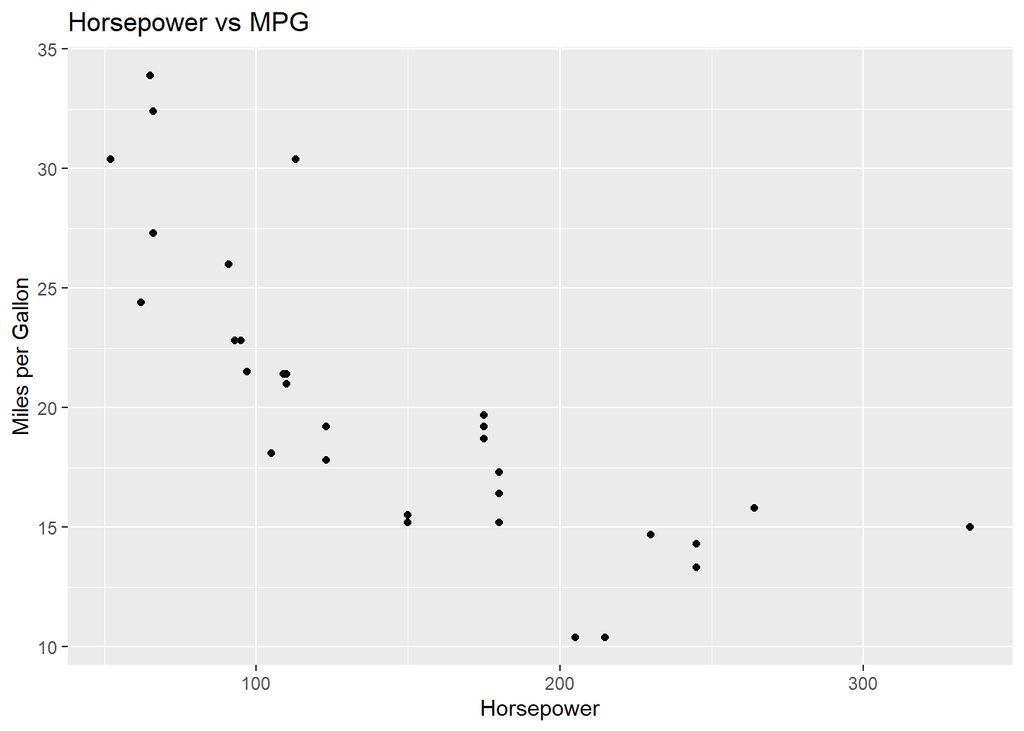

```r
ggplot2::ggplot(mtcars, ggplot2::aes(x = hp, y = mpg)) +
  ggplot2::geom_point() +
  ggplot2::labs(title = "Horsepower vs MPG",
       x = "Horsepower",
       y = "Miles per Gallon")
```

## Tidying data with `tidyr`

The `tidyr` package helps transform data into a tidy format. A dataset is tidy when:

1. Each variable forms a column.
2. Each observation forms a row.
3. Each type of observational unit forms a table.

For example, if we have data in a wide format, we can use `pivot_longer()` to convert it into a tidy format:

```r
wide_data <- tibble::tibble(
  id = 1:3,
  treatment_A = c(5, 10, 15),
  treatment_B = c(3, 6, 9)
)

tidy_data <- wide_data |>
  tidyr::pivot_longer(cols = starts_with("treatment"),
               names_to = "treatment",
               values_to = "result")
tidy_data
```

```
## # A tibble: 6 × 3
##      id treatment   result
##   <int> <chr>        <dbl>
## 1     1 treatment_A      5
## 2     1 treatment_B      3
## 3     2 treatment_A     10
## 4     2 treatment_B      6
## 5     3 treatment_A     15
## 6     3 treatment_B      9
```